# 16S_analysis

# Alpha Diversity

Not extremely useful, but people report it. Let’s analyze and graph the number of ASVs in our sample types Two categories: t-test (parametric) or Wilcoxon Test (non-parametric) Three + categories: ANOVA (parametric) or Kruskal-Wallis Test (non-parametric)

First, let’s get the number of ASVs (richness) per sample and add it to the mapping file.

```r
input_rar$map_loaded$rich <- specnumber(input_rar$data_loaded, MARGIN = 2)
```

> Note: since the data_loaded file has ASVs as rows, MARGIN must be set to 2.

```r
# Three or more categories
leveneTest(input_rar$map_loaded$rich ~ input_rar$map_loaded$combo_label)
```

```
## Levene's Test for Homogeneity of Variance (center = median)
##       Df F value Pr(>F)
## group  5  0.2465 0.9337
##       12
```

```r
# Variance homogeneous (p > 0.05)

m <- aov(input_rar$map_loaded$rich ~ input_rar$map_loaded$combo_label)
shapiro.test(m$residuals)
```

```
##
##  Shapiro-Wilk normality test
##
## data:  m$residuals
## W = 0.93436, p-value = 0.2315
```

```r
# Residuals normally distributed (p > 0.05)
```

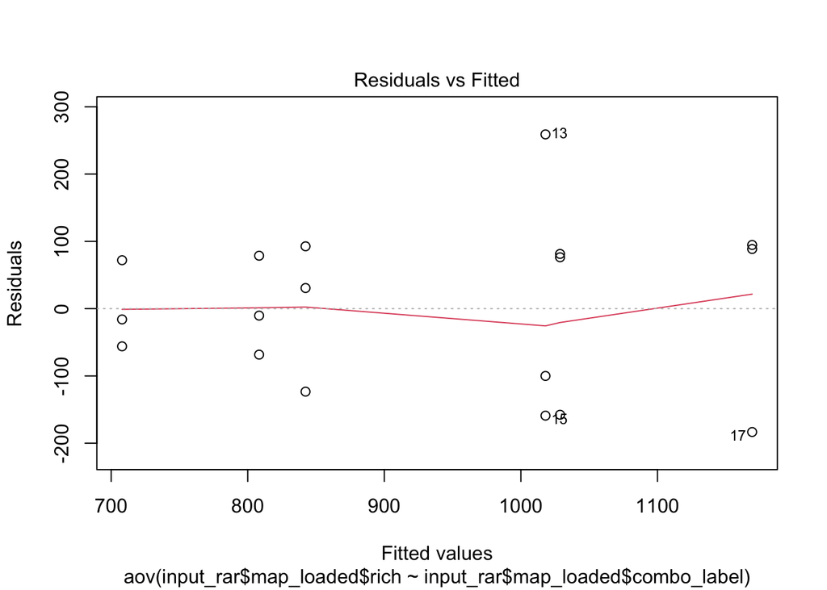

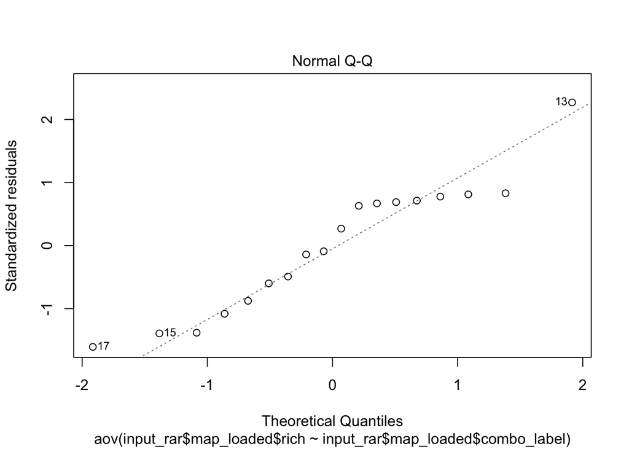

```
## hat values (leverages) are all = 0.3333333
##  and there are no factor predictors; no plot no. 5
```

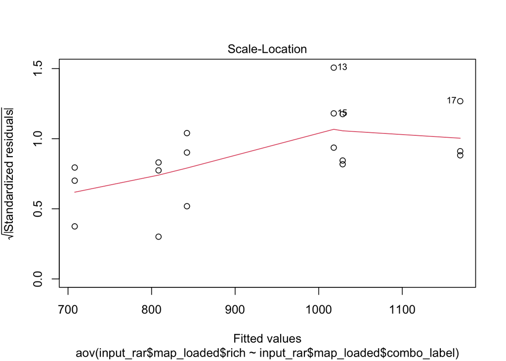

```r
# Other diagnostics - learn more here (https://data.library.virginia.edu/diagnostic-plots/)
plot(m) # Click in the console and hit Return to see each diagnostic plot
```

```r
summary(m)
```

```
##                                  Df Sum Sq Mean Sq F value Pr(>F)
## input_rar$map_loaded$combo_label  5 439581   87916   4.501 0.0153 *
## Residuals                        12 234377   19531
## ---
## Signif. codes:  0 '***' 0.001 '**' 0.01 '*' 0.05 '.' 0.1 ' ' 1
```

```r
TukeyHSD(m)
```

```
##   Tukey multiple comparisons of means
##     95% family-wise confidence level
##
## Fit: aov(formula = input_rar$map_loaded$rich ~ input_rar$map_loaded$combo_label)
##
## $`input_rar$map_loaded$combo_label`
##                           diff        lwr       upr     p adj
## GGc0-CRCcr0          -34.00000 -417.28401 349.28401 0.9995930
## GGm0-CRCcr0          186.33333 -196.95068 569.61735 0.5945036
## GGm3-CRCcr0         -134.33333 -517.61735 248.95068 0.8392637
## MMg0-CRCcr0          175.66667 -207.61735 558.95068 0.6482192
## NRt0-diluted-CRCcr0  327.00000  -56.28401 710.28401 0.1125053
## GGm0-GGc0            220.33333 -162.95068 603.61735 0.4302494
## GGm3-GGc0           -100.33333 -483.61735 282.95068 0.9445322
## MMg0-GGc0            209.66667 -173.61735 592.95068 0.4796635
## NRt0-diluted-GGc0    361.00000  -22.28401 744.28401 0.0692149
## GGm3-GGm0           -320.66667 -703.95068  62.61735 0.1229225
## MMg0-GGm0            -10.66667 -393.95068 372.61735 0.9999987
## NRt0-diluted-GGm0    140.66667 -242.61735 523.95068 0.8133743
## MMg0-GGm3            310.00000  -73.28401 693.28401 0.1424459
## NRt0-diluted-GGm3    461.33333   78.04932 844.61735 0.0157720
## NRt0-diluted-MMg0    151.33333 -231.95068 534.61735 0.7663168
```

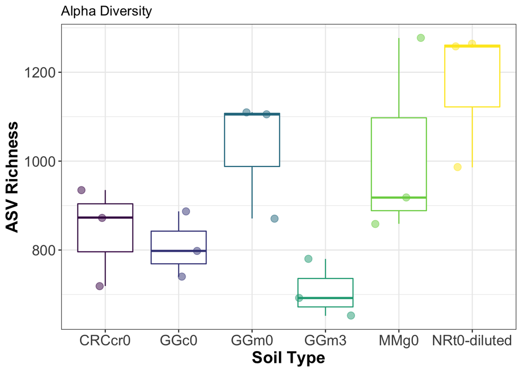

```r
p_alpha_div <- input_rar$map_loaded %>% ggplot(aes(combo_label, rich, color = combo_label)) +
  geom_boxplot(outlier.shape = NA) +
  geom_jitter(size = 3,
              alpha = 0.5) +
  labs(x = "Soil Type",
       y = "ASV Richness",
       colour = "combo_label",
       title = "Alpha Diversity") +
  scale_colour_viridis_d() +
  theme_bw() +
  theme(axis.title = element_text(face = "bold",
                                  size = 16),
        axis.text = element_text(size = 14),
        legend.position = "none")
p_alpha_div
```

# Beta Diversity

Let’s calculate Bray-Curtis dissimilarity, plot some PCoA ordinations, and run some stats.

## Bray-Curtis Matrix

```r
bc <- calc_dm(input_rar$data_loaded)
```

## Principle Coordinate Analysis (PCoA)

```r
pcoa <- cmdscale(bc, k = nrow(input_rar$map_loaded) - 1, eig = T)
```

## Variation Explained

```r
eigenvals(pcoa)/sum(eigenvals(pcoa)) # 25.7, 18.9 % variation explained
```

```
##  [1] 0.25646555 0.18875800 0.17601176 0.13149189 0.09485564 0.01711172
##  [7] 0.01588106 0.01476253 0.01381449 0.01345352 0.01309292 0.01218367
## [13] 0.01196859 0.01145934 0.01108072 0.00969941 0.00790920 0.00000000
```

```r
# Save Axis 1 and 2 to the mapping file
input_rar$map_loaded$Axis01 <- scores(pcoa)[,1]
input_rar$map_loaded$Axis02 <- scores(pcoa)[,2]

# Function for making a convex hull
find_hull <- function(df) df[chull(df$Axis01, df$Axis02),]

# Calculate hulls and save to dataframe
micro.hulls <- ddply(input_rar$map_loaded, c("combo_label"), find_hull)
```

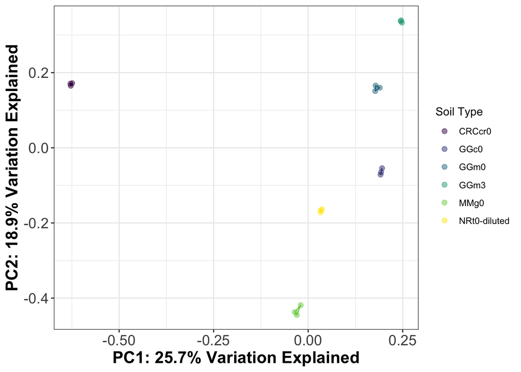

```r
p_pcoa <- input_rar$map_loaded %>% ggplot(
  aes(Axis01, Axis02, color = combo_label)) +
  geom_polygon(data = micro.hulls,
               aes(colour = combo_label),
               alpha = 0.1,
               show.legend = F) +
  geom_point(size = 2,
             alpha = 0.5) +
  labs(x = "PC1: 25.7% Variation Explained",
       y = "PC2: 18.9% Variation Explained",
       colour = "Soil Type") +
  scale_colour_viridis_d() +
  scale_fill_viridis_d() +
  theme_bw() +
  theme(legend.position = "right",
        axis.title = element_text(face = "bold",
                                  size = 16),
        axis.text = element_text(size = 14))
p_pcoa
```

## PERMANOVA

Test for differences in centroid of different PCoA hull groups.

```r
set.seed(1223) # To make reproducible
adonis(bc ~ input_rar$map_loaded$combo_label)
```

```
##
## Call:
## adonis(formula = bc ~ input_rar$map_loaded$combo_label)
##
## Permutation: free
## Number of permutations: 999
##
## Terms added sequentially (first to last)
##
##                                  Df SumsOfSqs MeanSqs F.Model      R2 Pr(>F)
## input_rar$map_loaded$combo_label  5    5.2162 1.04323  13.314 0.84727  0.001
## Residuals                        12    0.9403 0.07836         0.15273
## Total                            17    6.1564                 1.00000
##
## input_rar$map_loaded$combo_label ***
## Residuals
## Total
## ---
## Signif. codes:  0 '***' 0.001 '**' 0.01 '*' 0.05 '.' 0.1 ' ' 1
```

Significant effects of type.

## PERMDISP

Multivariate version of Levenne Test. Difference in variation in each factor level

```r
m1 <- betadisper(bc, input_rar$map_loaded$combo_label)
anova(m1) # Dispersion homogeneous for soil type
```

```
## Analysis of Variance Table
##
## Response: Distances
##           Df    Sum Sq    Mean Sq F value Pr(>F)
## Groups     5 0.0040075 0.00080149  1.2215 0.3572
## Residuals 12 0.0078737 0.00065614
```

# Taxonomic Analyses

Indicator taxa - SIMPER (Similarity Percentages) or MULTIPATT both take into account the number of samples that the taxa is present in within each group as well as abundance. SIMPER (list how much each ASV contributes to dissimilarity among groups).

## SIMPER

```r
sim <- simper(t(input_rar$data_loaded),
              input_rar$map_loaded$combo_label)
s <- summary(sim)
```

```r
head(s$GGm0_GGm3, n = 5)
```

```
##            average           sd     ratio       ava       avb     cumsum
## ASV_133 0.01955556 0.0002752976 71.034247  41.66667 1097.6667 0.02896819
## ASV_168 0.01687654 0.0009776743 17.261928   0.00000  911.3333 0.05396789
## ASV_67  0.01426543 0.0016168745  8.822844 540.66667 1311.0000 0.07509967
## ASV_79  0.01027778 0.0009244433 11.117803 231.66667  786.6667 0.09032443
## ASV_39  0.01021605 0.0016878032  6.052868 420.66667  972.3333 0.10545775
```

Average is the proportion contribution, cumsum is cumulative, ava and avb are mean sequence abundances per group.

## MULTIPATT

MULTIPATT (list ASVs associated with each group) Difference between this and SIMPER is in what it is reporting: MULTIPATT doesn’t give a value for every ASV It only outputs important ASVs.

**Excluded for brevity.**

```
set.seed(1223) # For reproducibility
mp <- multipatt(t(input_rar$data_loaded),
                input_rar$map_loaded$combo_label,
                func = "IndVal.g",
                control = how(nperm=999))
summary(mp)
```

## Main taxa at different levels

Let’s quickly just use the mctoolsr base functions Summarize at family level. Choose different levels with the level argument

```r
tax_sum_families <- summarize_taxonomy(input_rar, level = 5, report_higher_tax = FALSE) #level 5 = families, level 6 = genus
```

### Heatmap

mctoolsr Default heatmap, which uses ggplot2 in the background so we can use normal ggplot2 syntax numbers are percent relative abundances

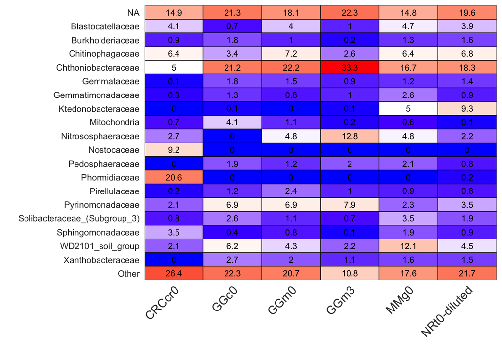

```r
plot_ts_heatmap(tax_sum_families,
                input_rar$map_loaded,
                0.01,
                'combo_label',
                rev_taxa = T) +
  coord_flip() +
  theme(axis.text.x = element_text(size = 12, angle = 45, vjust = 1))
```

### Stacked Bar Chart

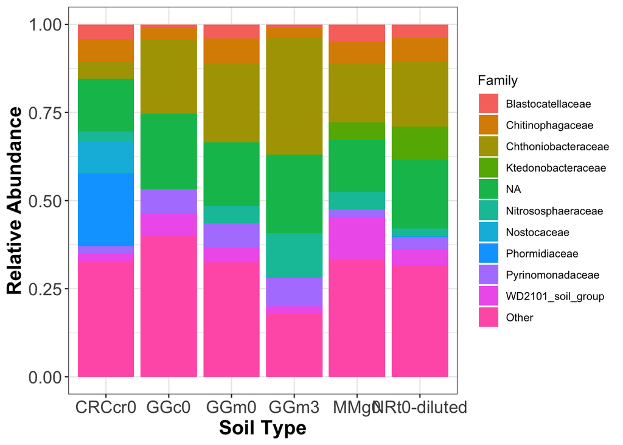

```r
plot_taxa_bars(tax_sum_families,
               input_rar$map_loaded,
               "combo_label",
               num_taxa = 10) +
  labs(x = "Soil Type", y = "Relative Abundance", fill = "Family") +
  theme_bw() +
  theme(axis.title = element_text(face = "bold", size = 16),
        axis.text = element_text(size = 14))
```

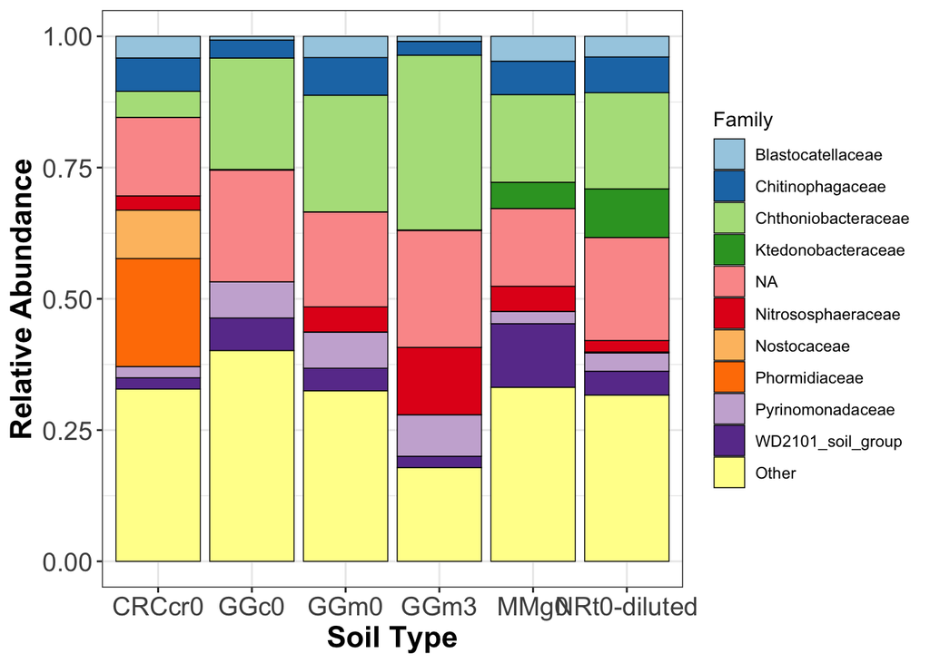

```r
bars <- plot_taxa_bars(tax_sum_families,
                       input_rar$map_loaded,
                       "combo_label",
                       num_taxa = 10,
                       data_only = TRUE) # allows us to save the data and not make the plot
ggplot(bars, aes(group_by, mean_value, fill = taxon)) +
  geom_bar(stat = "identity", colour = "black", size = 0.25) +
  labs(x = "Soil Type", y = "Relative Abundance", fill = "Family") +
  scale_fill_brewer(palette = "Paired") +
  theme_bw() +
  theme(axis.title = element_text(face = "bold", size = 16),
        axis.text = element_text(size = 14))
```

### Kruskal-Wallis Test

Test (run a Kruskal-Wallis test on all families with mean rel abund. > filter_level in at least one of the factor levels) which families are different between the sample types (testing all at once)

```r
taxa_summary_by_sample_type(tax_sum_families,
                            input_rar$map_loaded,
                            type_header = 'combo_label',
                            filter_level = 0.05, # cut off for relative abundance
                            test_type = 'KW') # Bonferroni corection imporant since you did many tests at once
```

```
##                           pvals   pvalsBon   pvalsFDR     CRCcr0        GGc0
## Nostocaceae         0.004826148 0.04343533 0.04343533 0.09207407 0.000000000
## Chthoniobacteraceae 0.006928052 0.06235247 0.03117624 0.04965432 0.212172840
## Nitrososphaeraceae  0.007147275 0.06432547 0.02144182 0.02733333 0.000000000
## Phormidiaceae       0.007455090 0.06709581 0.01677395 0.20564198 0.000000000
## WD2101_soil_group   0.007787003 0.07008302 0.01401660 0.02149383 0.061962963
## NA                  0.008254482 0.07429034 0.01238172 0.14944444 0.212580247
## Ktedonobacteraceae  0.008800570 0.07920513 0.01131502 0.00000000 0.001481481
## Pyrinomonadaceae    0.011914313 0.10722882 0.01340360 0.02149383 0.068925926
## Chitinophagaceae    0.023378768 0.21040891 0.02337877 0.06353086 0.034185185
##                             GGm0         GGm3         MMg0 NRt0-diluted
## Nostocaceae         0.0000000000 0.0000000000 0.0000000000  0.000000000
## Chthoniobacteraceae 0.2221481481 0.3329135802 0.1669753086  0.183160494
## Nitrososphaeraceae  0.0477901235 0.1282098765 0.0479259259  0.021716049
## Phormidiaceae       0.0000000000 0.0000000000 0.0001975309  0.001864198
## WD2101_soil_group   0.0428395062 0.0216049383 0.1212098765  0.045469136
## NA                  0.1805925926 0.2226790123 0.1480864198  0.196395062
## Ktedonobacteraceae  0.0003950617 0.0009382716 0.0499382716  0.092530864
## Pyrinomonadaceae    0.0690617284 0.0791358025 0.0230864198  0.034814815
## Chitinophagaceae    0.0717037037 0.0263827160 0.0637283951  0.068049383
```

```r
tax_sum_phyla <- summarize_taxonomy(input_rar, level = 2, report_higher_tax = FALSE) #level 5 = families, level 6 = genus
```

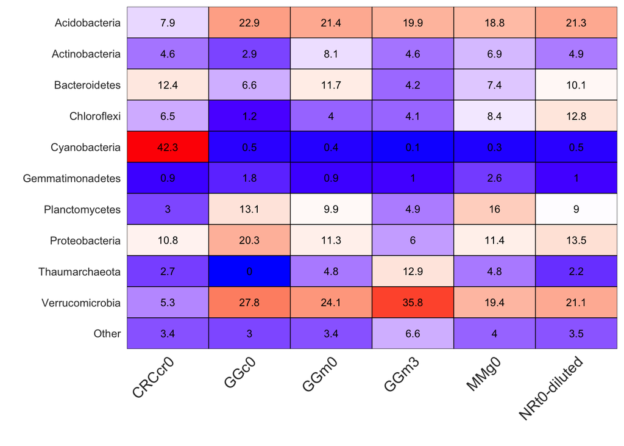

```r
# Add some customization
plot_ts_heatmap(tax_sum_phyla,
                input_rar$map_loaded,
                0.01,
                'combo_label',
                rev_taxa = T) +
  coord_flip() +
  theme(axis.text.x = element_text(size = 12, angle = 45, vjust = 1))
```

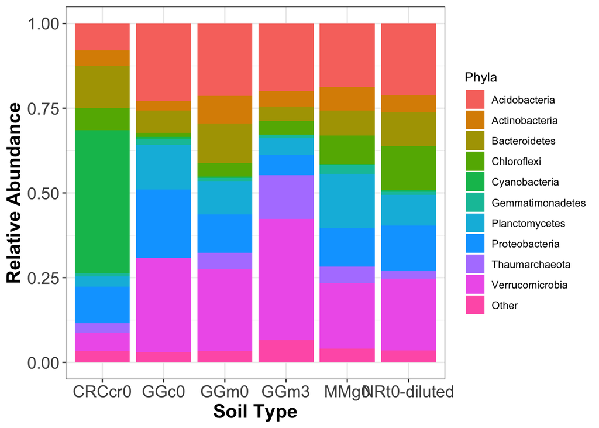

```r
# Add some customization
plot_taxa_bars(tax_sum_phyla,
               input_rar$map_loaded,
               "combo_label",
               num_taxa = 10) +
  labs(x = "Soil Type", y = "Relative Abundance", fill = "Phyla") +
  theme_bw() +
  theme(axis.title = element_text(face = "bold", size = 16),
        axis.text = element_text(size = 14))
```

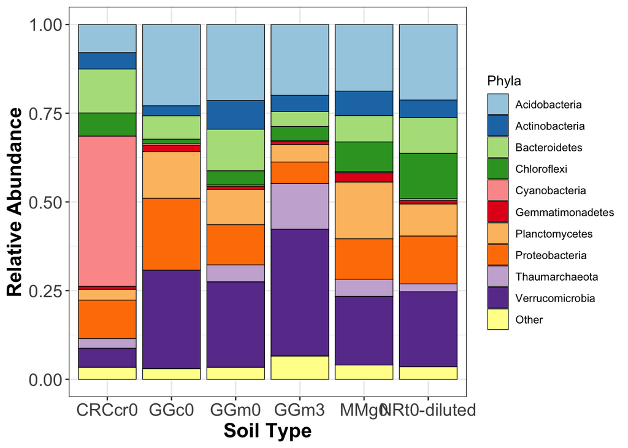

```r
bars <- plot_taxa_bars(tax_sum_phyla,
                       input_rar$map_loaded,
                       "combo_label",
                       num_taxa = 10,
                       data_only = TRUE) # allows us to save the data and not make the plot

ggplot(bars, aes(group_by, mean_value, fill = taxon)) +
  geom_bar(stat = "identity", colour = "black", size = 0.25) +
  labs(x = "Soil Type", y = "Relative Abundance", fill = "Phyla") +
  scale_fill_brewer(palette = "Paired") +
  theme_bw() +
  theme(axis.title = element_text(face = "bold", size = 16),
        axis.text = element_text(size = 14))
```

```r
# Test (run a Kruskal-Wallis test on all families with mean rel abund. > filter_level in at least one of the factor levels)
# which phyla are different between the sample types (testing all at once)
taxa_summary_by_sample_type(tax_sum_phyla,
                            input_rar$map_loaded,
                            type_header = 'combo_label',
                            filter_level = 0.05, # cut off for relative abundance
                            test_type = 'KW') # Bonferroni correction important since you did many tests at once
```

```
##                       pvals   pvalsBon   pvalsFDR     CRCcr0         GGc0
## Verrucomicrobia 0.005371597 0.04834437 0.04834437 0.05349383 2.778025e-01
## Bacteroidetes   0.007345318 0.06610786 0.03305393 0.12403704 6.572840e-02
## Thaumarchaeota  0.007585506 0.06826955 0.02275652 0.02733333 4.938272e-05
## Chloroflexi     0.007787003 0.07008302 0.01752076 0.06518519 1.179012e-02
## Planctomycetes  0.008335003 0.07501503 0.01500301 0.03029630 1.313951e-01
## Actinobacteria  0.013113432 0.11802089 0.01967015 0.04598765 2.856790e-02
## Proteobacteria  0.013625087 0.12262578 0.01751797 0.10832099 2.026173e-01
## Acidobacteria   0.015871546 0.14284392 0.01785549 0.07914815 2.287531e-01
## Cyanobacteria   0.022307043 0.20076339 0.02230704 0.42341975 5.074074e-03
##                        GGm0         GGm3        MMg0 NRt0-diluted
## Verrucomicrobia 0.240827160 0.3575432099 0.193864198  0.211456790
## Bacteroidetes   0.117395062 0.0418271605 0.074407407  0.101024691
## Thaumarchaeota  0.047790123 0.1287654321 0.048123457  0.022098765
## Chloroflexi     0.040074074 0.0405679012 0.083790123  0.127987654
## Planctomycetes  0.099283951 0.0493086420 0.159864198  0.090172840
## Actinobacteria  0.081000000 0.0459259259 0.068802469  0.049209877
## Proteobacteria  0.113246914 0.0604814815 0.114197531  0.135061728
## Acidobacteria   0.213691358 0.1993456790 0.187679012  0.212641975
## Cyanobacteria   0.004024691 0.0005185185 0.002888889  0.005271605
```

Verrucomicrobia is significantly different!

# Variation between replicates - graphing individual samples

```r
tax_sum_phyla <- summarize_taxonomy(input_rar, level = 2, report_higher_tax = FALSE) #level 5 = families, level 6 = genus
```

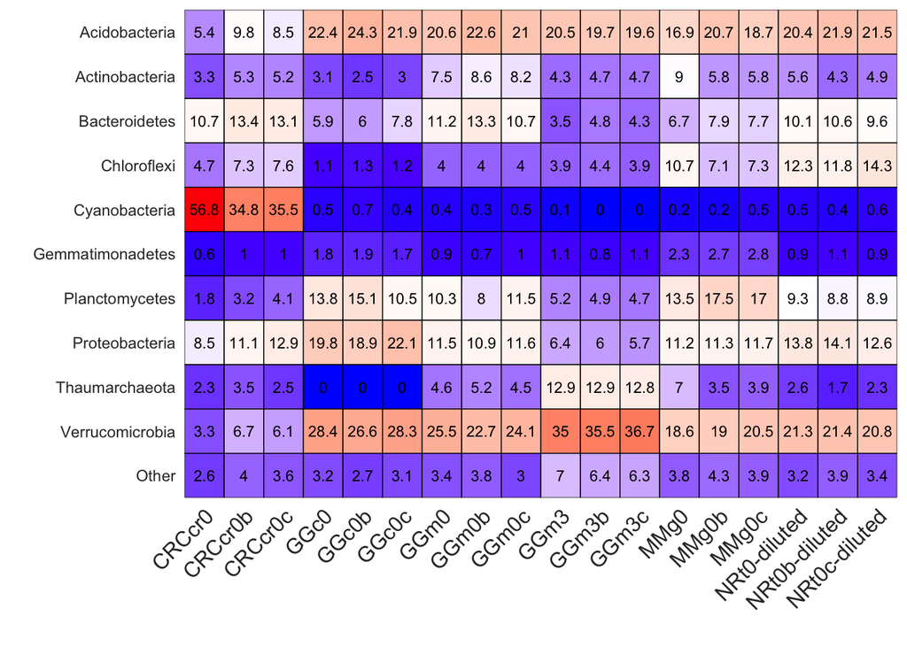

```r
plot_ts_heatmap(tax_sum_phyla,
                input_rar$map_loaded,
                0.01,
                'names',
                rev_taxa = T) +
  coord_flip() +
  theme(axis.text.x = element_text(size = 12, angle = 45, vjust = 1))
```

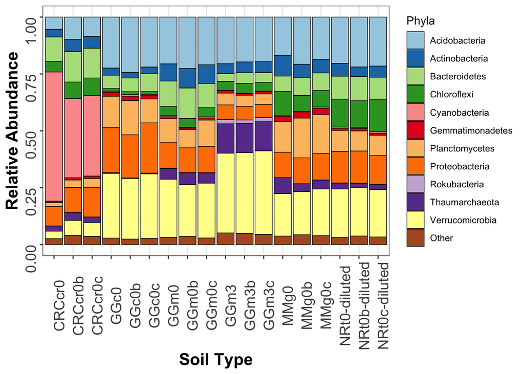

```r
bars <- plot_taxa_bars(tax_sum_phyla,
                       input_rar$map_loaded,
                       "names",
                       num_taxa = 11,
                       data_only = TRUE) # allows us to save the data and not make the plot
ggplot(bars, aes(group_by, mean_value, fill = taxon)) +
  geom_bar(stat = "identity", colour = "black", size = 0.25) +
  labs(x = "Soil Type", y = "Relative Abundance", fill = "Phyla") +
  scale_fill_brewer(palette = "Paired") +
  theme_bw() +
  theme(axis.title = element_text(face = "bold", size = 16),
        axis.text = element_text(size = 14, angle = 90))
```

Looks good to me.